# Final Project - McDonalds

Andrew Tran

May 11, 2018

## Introduction

McDonald’s is the world’s largest restaurant chain by revenue, serving over 69 million customers daily in over 100 countries. It is the stereotypical ideal that comes to mind when one thinks of fast food, known for its hamburgers, fries, soft drinks, and other menu items. In today’s current culture, with an increased focus on having a healthy lifestyle, people often disdain McDonald’s for its supposed unhealtiness, its food and drink loaded with fat, grease, and sugar. But does McDonald’s really deserve such a bad reputation?

As a person who has eaten at the UMD Stamp McDonalds an untold number of times, I decided to create this tutorial on exploring the nutrition behind the menu items sold at McDonald’s.

## Part 1 - Data Loading and Cleaning

The very first thing we must do is to retrieve the data we wish to look at and analyze. In this case, we will be using a free dataset provided by Kaggle:

https://www.kaggle.com/mcdonalds/nutrition-facts

Once we’ve downloaded the dataset to our computer, let’s load it up into R-Studio, along with a few basic libraries we will need.

Of course, if you want to look at the official information as provided by McDonald’s, you are always free to visit their official nutritional information calculator for yourself:

https://www.mcdonalds.com/us/en-us/about-our-food/nutrition-calculator.html

```r
library(tidyverse)
```

```r
library(ggplot2)
library(dplyr)


# Use the read_csv function to load the dataset into a variable we can use.
menu <- read_csv("C:/Users/Andrew/Desktop/College/CMSC320/Final/menu.csv")
menu
```

```
## # A tibble: 260 x 24
##    Category  Item     `Serving Size` Calories `Calories from ~ `Total Fat`
##    <chr>     <chr>    <chr>             <int>            <int>       <dbl>
##  1 Breakfast Egg McM~ 4.8 oz (136 g)      300              120       13.0
##  2 Breakfast Egg Whi~ 4.8 oz (135 g)      250               70        8.00
##  3 Breakfast Sausage~ 3.9 oz (111 g)      370              200       23.0
##  4 Breakfast Sausage~ 5.7 oz (161 g)      450              250       28.0
##  5 Breakfast Sausage~ 5.7 oz (161 g)      400              210       23.0
##  6 Breakfast Steak &~ 6.5 oz (185 g)      430              210       23.0
##  7 Breakfast Bacon, ~ 5.3 oz (150 g)      460              230       26.0
##  8 Breakfast Bacon, ~ 5.8 oz (164 g)      520              270       30.0
##  9 Breakfast Bacon, ~ 5.4 oz (153 g)      410              180       20.0
## 10 Breakfast Bacon, ~ 5.9 oz (167 g)      470              220       25.0
## # ... with 250 more rows, and 18 more variables: `Total Fat (% Daily
## #   Value)` <int>, `Saturated Fat` <dbl>, `Saturated Fat (% Daily
## #   Value)` <int>, `Trans Fat` <dbl>, Cholesterol <int>, `Cholesterol (%
## #   Daily Value)` <int>, Sodium <int>, `Sodium (% Daily Value)` <int>,
## #   Carbohydrates <int>, `Carbohydrates (% Daily Value)` <int>, `Dietary
## #   Fiber` <int>, `Dietary Fiber (% Daily Value)` <int>, Sugars <int>,
## #   Protein <int>, `Vitamin A (% Daily Value)` <int>, `Vitamin C (% Daily
## #   Value)` <int>, `Calcium (% Daily Value)` <int>, `Iron (% Daily
## #   Value)` <int>
```

Now that our dataset has been loaded in R-Studio as a dataframe, we can see that it contains 260 different McDonald’s menu items (entities, or rows), each with 24 different attributes (columns). At first glance, this dataset appears to be very well organized too, so we may not need to do much cleaning with it. Let’s use colnames() to see every single attribute used in this dataframe, and find out what we can work with.

```r
colnames(menu)
```

```
##  [1] "Category"                      "Item"
##  [3] "Serving Size"                  "Calories"
##  [5] "Calories from Fat"             "Total Fat"
##  [7] "Total Fat (% Daily Value)"     "Saturated Fat"
##  [9] "Saturated Fat (% Daily Value)" "Trans Fat"
## [11] "Cholesterol"                   "Cholesterol (% Daily Value)"
## [13] "Sodium"                        "Sodium (% Daily Value)"
## [15] "Carbohydrates"                 "Carbohydrates (% Daily Value)"
## [17] "Dietary Fiber"                 "Dietary Fiber (% Daily Value)"
## [19] "Sugars"                        "Protein"
## [21] "Vitamin A (% Daily Value)"     "Vitamin C (% Daily Value)"
## [23] "Calcium (% Daily Value)"       "Iron (% Daily Value)"
```

Looks pretty good so far. There is however, one problem. Several of these attributes are missing their respective units of measurement. “% Daily Values” are easy enough to understand, but what about things like Sodium or Total Fat? What exactly does it mean if an Egg McMuffin possesses a value of 3 for Sugars and a value of 17 for Protein? We can make things clearer than this.

Let’s add the official unit of measurement to their respective units. We can do so by using the rename function along with a pipeline (the “%>%” symbol).

```r
# Note that since our attribute names possess spaces, we will need to use backtabs `` in order to access them.
# For example: `attribute name`
menu <- menu %>%
  rename( `Total Fat (g)`=`Total Fat`,
         `Saturated Fat (g)`=`Saturated Fat`,
         `Trans Fat (g)`=`Trans Fat`,
         `Cholesterol (mg)`=`Cholesterol`,
         `Sodium (mg)`=`Sodium`,
         `Carbohydrates (g)`=`Carbohydrates`,
         `Dietary Fiber (g)`=`Dietary Fiber`,
         `Sugars (g)`=`Sugars`,
         `Protein (g)`=`Protein`)

colnames(menu)
```

```
##  [1] "Category"                      "Item"
##  [3] "Serving Size"                  "Calories"
##  [5] "Calories from Fat"             "Total Fat (g)"
##  [7] "Total Fat (% Daily Value)"     "Saturated Fat (g)"
##  [9] "Saturated Fat (% Daily Value)" "Trans Fat (g)"
## [11] "Cholesterol (mg)"              "Cholesterol (% Daily Value)"
## [13] "Sodium (mg)"                   "Sodium (% Daily Value)"
## [15] "Carbohydrates (g)"             "Carbohydrates (% Daily Value)"
## [17] "Dietary Fiber (g)"             "Dietary Fiber (% Daily Value)"
## [19] "Sugars (g)"                    "Protein (g)"
## [21] "Vitamin A (% Daily Value)"     "Vitamin C (% Daily Value)"
## [23] "Calcium (% Daily Value)"       "Iron (% Daily Value)"
```

## Part 2 - Exploratory Data Analysis (EDA)

Now that we have our data, let try to do some analyzing, and see if we can find a few things out or two.

Let’s start with something simple. For most people, the most common criticisms of fast food are high fat content, sodium, calorie count, and sugar. Let’s try finding out the average values for these attributes for all food categories offered by McDonald’s.

To do so, we can use the summarize and group_by functions. Group_by allows use to group these menu items by a certain attribute, while summarize allows us to collapse the dataframe into a single row containing the desired attribute summaries we want (e.g. mean, median, max, min, etc.)

```r
menu_averages <- menu %>%
  group_by(Category) %>%
  summarize(`Average Calories`=mean(Calories),
            `Average Sodium (mg)`=mean(`Sodium (mg)`),
            `Average Total Fat (g)` = mean(`Total Fat (g)`),
            `Average Sugars (g)` = mean(`Sugars (g)`))


menu_averages
```

```
## # A tibble: 9 x 5
##   Category       `Average Calories` `Average Sodium (~ `Average Total Fat~
##   <chr>                       <dbl>              <dbl>               <dbl>
## 1 Beef & Pork                   494             1021               24.9
## 2 Beverages                     114               41.5              0.0926
## 3 Breakfast                     527             1211               27.7
## 4 Chicken & Fish                553             1258               27.0
## 5 Coffee & Tea                  284              137                8.02
## 6 Desserts                      222              117                7.36
## 7 Salads                        270              588               11.8
## 8 Smoothies & S~                531              184               14.1
## 9 Snacks & Sides                246              396               10.5
## # ... with 1 more variable: `Average Sugars (g)` <dbl>
```

Oho. These numbers do appear to be quite high. But what exactly do they mean? Perhaps we are putting too much focus on raw values at this point. To understand and go one step further, let’s put this in context with the % Daily Values required of a normal 2000 Calorie diet. After all, a seemingly high amount of fat, sodium, sugar may actually mean nothing if it is quit low in terms of your actual daily needs.

Let us again use summarize and group_by to find out our wanted percentages. One thing is missing from our original dataset however: the % daily value in regards to calories per menu item. We can add this in using the mutate function, which adds new attributes to datasets based on the result of an expression. Let us again assume we are using a 2000 Calorie Diet, as specified on today’s current nutrition labels.

```r
menu <- menu %>%
  # mutate is used to add new attributes based on the result of a given expression
  mutate(`Calories (% Daily Value)` = as.integer((Calories/2000) * 100))

# Use summarize and group_by to obtain the average daily values we want for each item category
menu_averages <- menu %>%
  group_by(Category) %>%
  summarize(`Average Calories (% Daily Value)`=mean(`Calories (% Daily Value)`),
            `Average Sodium (% Daily Value)`=mean(`Sodium (% Daily Value)`),
            `Average Total Fat (% Daily Value)` = mean(`Total Fat (% Daily Value)`),
            # In terms of nutrition, sugar falls under carbohydrates for % daily values
            `Average Carbohydrates (% Daily Value)` = mean(`Carbohydrates (% Daily Value)`))
```

Let’s try putting our newfound data onto plots, so we can more easily visualize our findings. To do so, we will be using the ggplot package. Plotting, or more formally “data visualization” is an extremely useful tool for any data scientist, allowing us to easily see trends or insights into dataset characteristics.

ggplot is an extremely versatile and useful package, designed to work well with the tidyverse set of packages. For more information and resources on this package, look here:

http://ggplot2.tidyverse.org/ https://www.rstudio.com/wp-content/uploads/2015/03/ggplot2-cheatsheet.pdf

In this case, we will be using a bar plot, commonly used to visualize a continuous variable to a categorical (or discrete) variable.

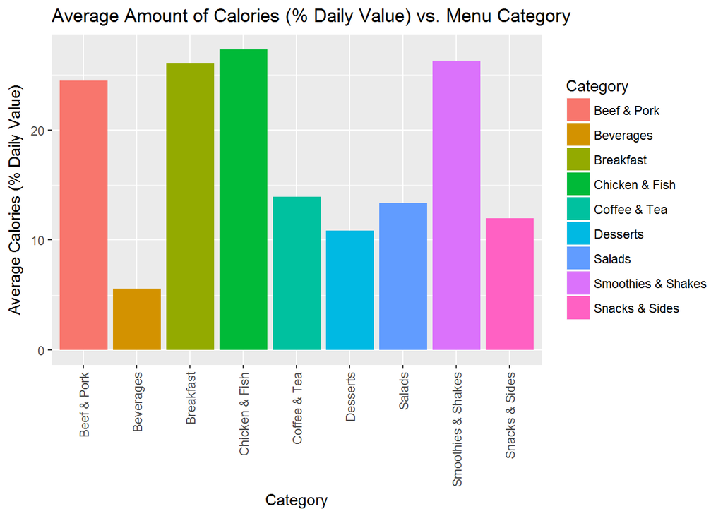

```r
menu_averages %>%
  ggplot(mapping=aes(x=Category, y=`Average Calories (% Daily Value)`)) +
    geom_bar(aes(fill=Category), stat="identity") + ggtitle("Average Amount of Calories (% Daily Value) vs. Menu Category") + theme(axis.text.x=element_text(angle=90,hjust=1,vjust=0.5))
```

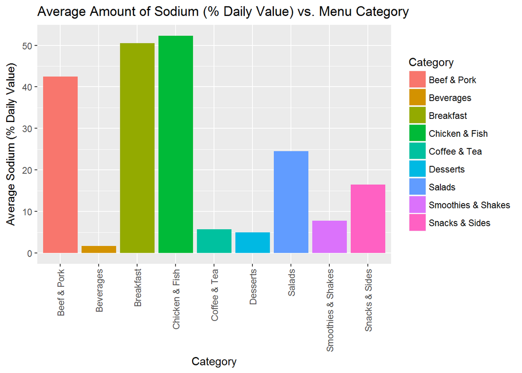

```r
# plot mean sodium
menu_averages %>%
  ggplot(mapping=aes(x=Category, y=`Average Sodium (% Daily Value)`)) +
    geom_bar(aes(fill=Category), stat="identity") + ggtitle("Average Amount of Sodium (% Daily Value) vs. Menu Category") + theme(axis.text.x=element_text(angle=90,hjust=1,vjust=0.5))
```

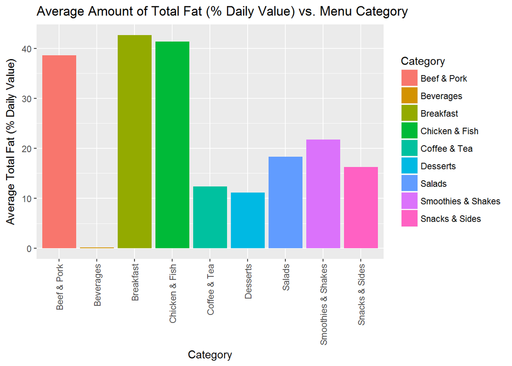

```r
# plot mean total fat
menu_averages %>%
  ggplot(mapping=aes(x=Category, y=`Average Total Fat (% Daily Value)`)) +
    geom_bar(aes(fill=Category), stat="identity") + ggtitle("Average Amount of Total Fat (% Daily Value) vs. Menu Category") + theme(axis.text.x=element_text(angle=90,hjust=1,vjust=0.5))
```

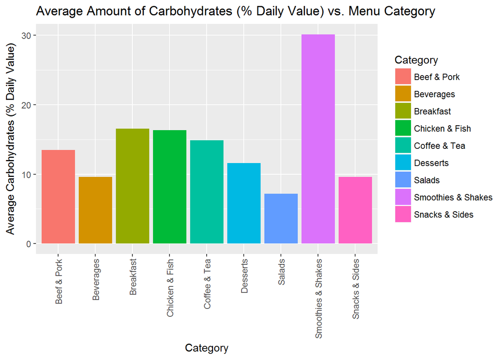

```r
# plot mean sugars
menu_averages %>%
  ggplot(mapping=aes(x=Category, y=`Average Carbohydrates (% Daily Value)`)) +
    geom_bar(aes(fill=Category), stat="identity") + ggtitle("Average Amount of Carbohydrates (% Daily Value) vs. Menu Category") + theme(axis.text.x=element_text(angle=90,hjust=1,vjust=0.5))
```

Well now, this certainly isn’t looking too good. We can see that Beef & Pork, Breakfast, and Chicken & Fish category menu items easily break over 40 % of one’s daily sodium intake. Likewise, they hover around 40% of a person’s daily intake of fat. Somewhat unsurprisingly, Smoothies & Shakes are also extremely high in sugar, averaging around 30% of one’s daily recommended amount of sugar. Although, it is interesting to note that they easily outstrip Desserts in terms of % Daily Value for Sugar in a ratio of almost 3:1. Perhaps McDonald’s really does deserve its reputation as unhealthy, salty, sugary, fatty goodness.

Well, with that concluded, let us now ask another interesting question: Just how much exactly does total fat contribute towards Calorie count? That is, while we may know McDonald’s menu items to be high in terms of fat and calories, just how many calories are due to to fat? Let’s find out using mutate and ggplot.

This time, we will be using a scatterplot, which is used to visualize the distributions between two attributes. We will also be using a regression line (“geom_smooth”), which attempts to predict the relationship between two attributes and plots out this prediction accordingly.

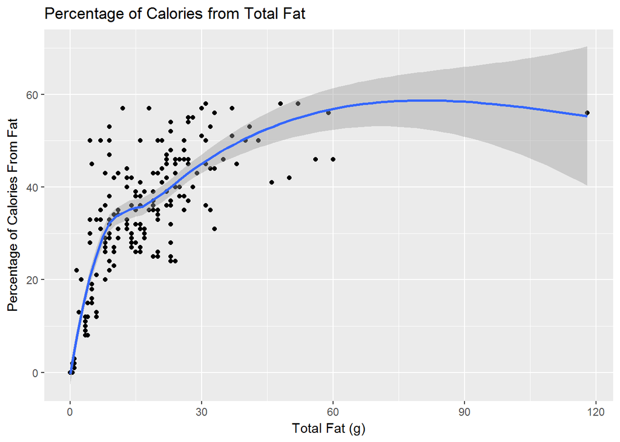

```r
menu <- menu %>%
  mutate(`Percentage of Calories From Fat`= as.integer((`Calories from Fat`/`Calories`) * 100))

menu %>%
  ggplot(aes(x=`Total Fat (g)`, y = `Percentage of Calories From Fat`)) + geom_point() + ggtitle("Percentage of Calories from Total Fat") + geom_smooth()
```

Oooooo. Now this is quite intriguing. We can see that, regardless of menu item category, as the amount of fat in a menu item increases, the more its Calories are due to the amount of fat it contains also increases, eventually peaking aroung 60%. It also seems that a large number of menu items tend to however around the 30 - 40% range. But what’s that there, at the very far right of the graph? Is there really some item on the McDonald’s menu that actually possesses near 120 grams of fat? What on earth?

I’m getting very curious now. We can see from this current plot that several McDonald’s menu items possess extremely high amounts of total fat (around 50+ grams). Let’s see what they are. To do so, we can use the arrange and slice functions. The arrange function sorts entities by attribute, and can sort by either increasing or decreasing value of attribute. The slice function can be used to take a look at a certain “slice” of a dataset, rather than its full contents.

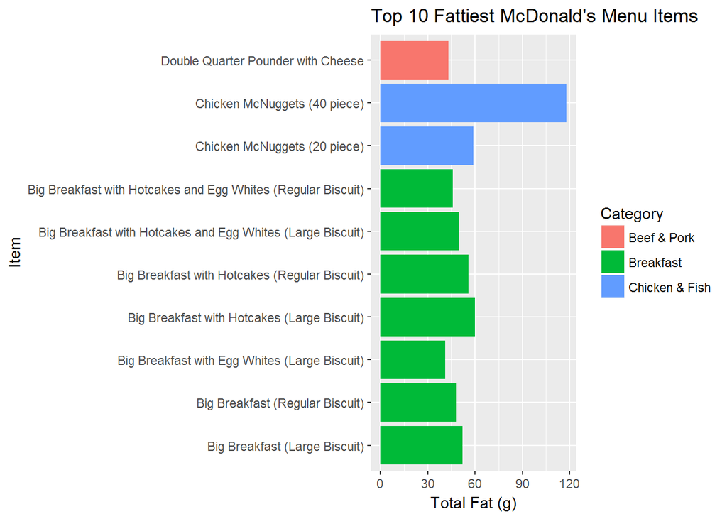

```r
menu %>%
  arrange(desc(`Total Fat (g)`)) %>%
  slice(1:10) %>%
  ggplot(aes(x=Item, y =`Total Fat (g)`, fill=Category)) + geom_bar(stat="identity") + ggtitle("Top 10 Fattiest McDonald's Menu Items") + coord_flip()
```